# FINAL PROJECT

#### Mô hình cho Forward

```r
set.seed(123) # Đặt seed
split = sample.split(fw_data$value, SplitRatio = 0.7) # 70% train
fw_train = subset(fw_data, split == TRUE)
fw_test = na.omit(subset(fw_data, split == FALSE))
```

```r
er_fw <- er_func(fw_train)
print(er_fw)
```

```
##  [1] 6835798 6682892 6581736 6512157 6489519 6520156 6515640 6511491 6510542
## [10] 6514428 6518207 6512600 6505908 6510104 6510984 6501839 6503068 6503929
## [19] 6499738 6500062 6499059 6499282 6498211 6497057 6496392 6496041
```

```r
print(which.min(er_fw))
```

```
## [1] 5
```

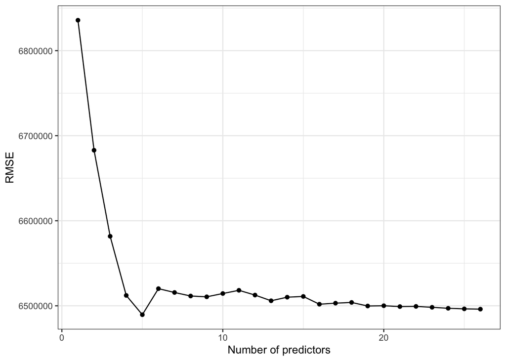

```r
ggplot(data = data.frame(x = 1:length(er_fw), y = er_fw), mapping = aes(x = x, y = y)) +
  geom_point() +
  geom_line() +
  labs(x = "Number of predictors", y = "RMSE") +
  theme_bw()
```

Dễ thấy 5 biến là tốt nhất cho mô hình hồi quy của tiền đạo

```r
out_subset_train_player <- regsubsets(
  value ~ .,
  data = fw_train,
  nvmax = 5,
  method = "forward"
)

sum_player <- summary(out_subset_train_player)
print(sum_player$cp)
```

```
## [1] 284.78032 168.48684 100.53183  54.41612  38.25835
```

```r
selected_vars <- names(coef(out_subset_train_player, 5))[-1]
print(selected_vars)
```

```
## [1] "finishing"    "ball_control" "acceleration" "reactions"    "vision"
```

```r
# Model hồi quy với 5 biến được chọn
f_best_fw = as.formula(paste("value ~", paste(selected_vars, collapse = " + ")))
cat("Best Model Formula:\n")
```

```
## Best Model Formula:
```

```r
print(f_best_fw)
```

```
## value ~ finishing + ball_control + acceleration + reactions +
##     vision
```

```r
model_fw_av <- lm(f_best_fw, data = fw_train)

# Gọi hàm đánh giá
result_fw = evaluate_model(model = model_fw_av,
                          train_data = fw_train,
                          test_data = fw_test,
                          target_col = "value")
```

```
## Test results
## RMSE:  4625396
## R2_score:  0.3591482
```

```r
# Kết quả trả về là danh sách RMSE và R2
print(result_fw)
```

```
## $RMSE
## [1] 4625396
##
## $R2
## [1] 0.3591482
```

R2 = 0.3591482 cho thấy model dự đoán không tốt, lệch 4625396 so với thực tế đối với tiền đạo

#### Chẩn đoán mô hình (cho cả 4 nhóm)

##### GK

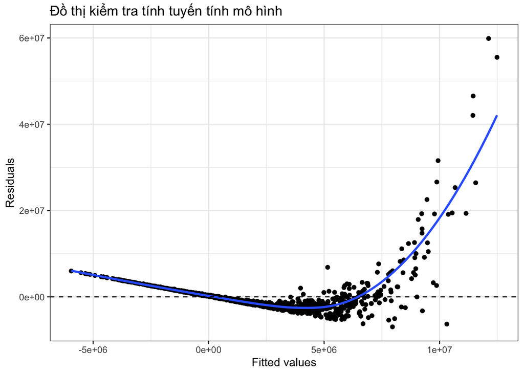

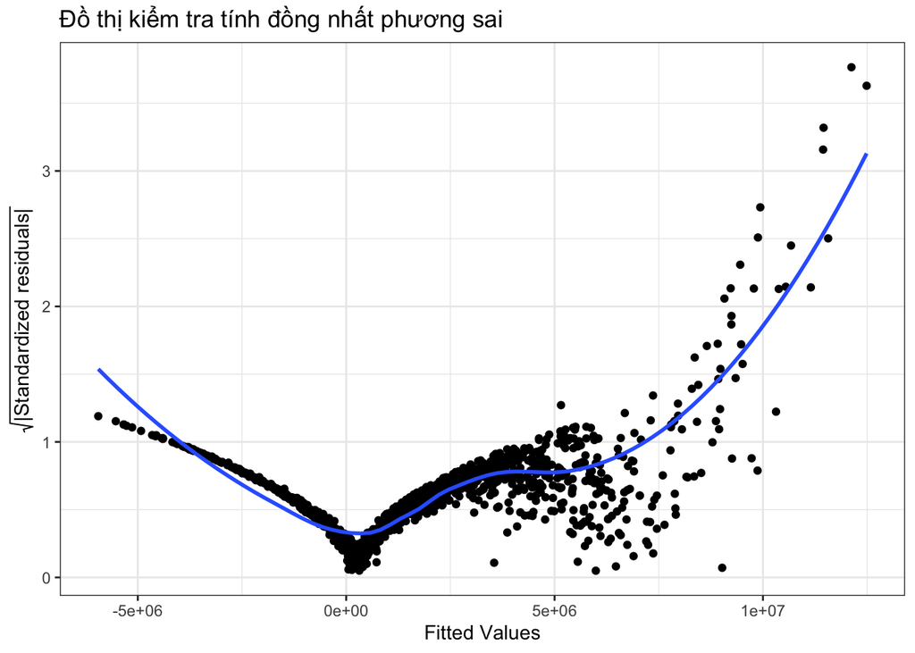

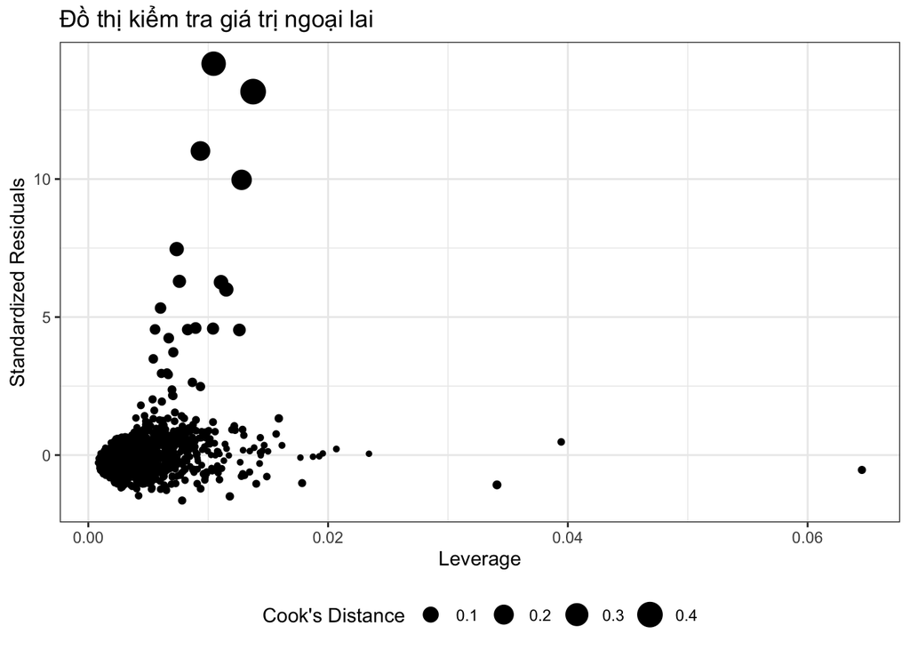

```r
model_diagnosis(model_gk_av)
```

##### Mid

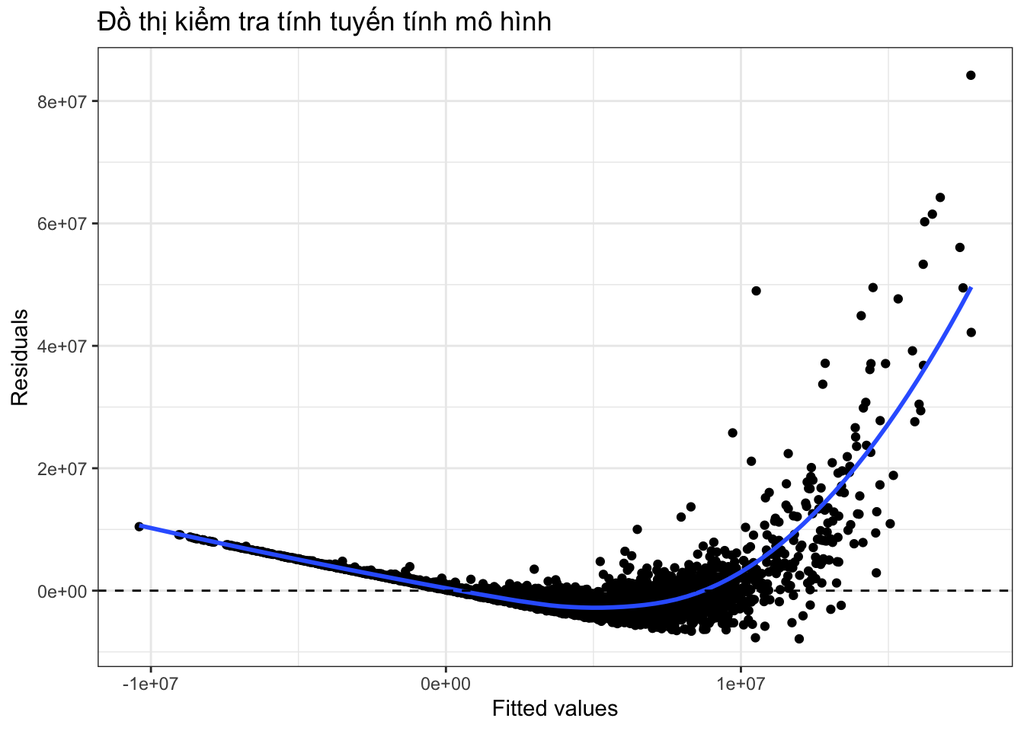

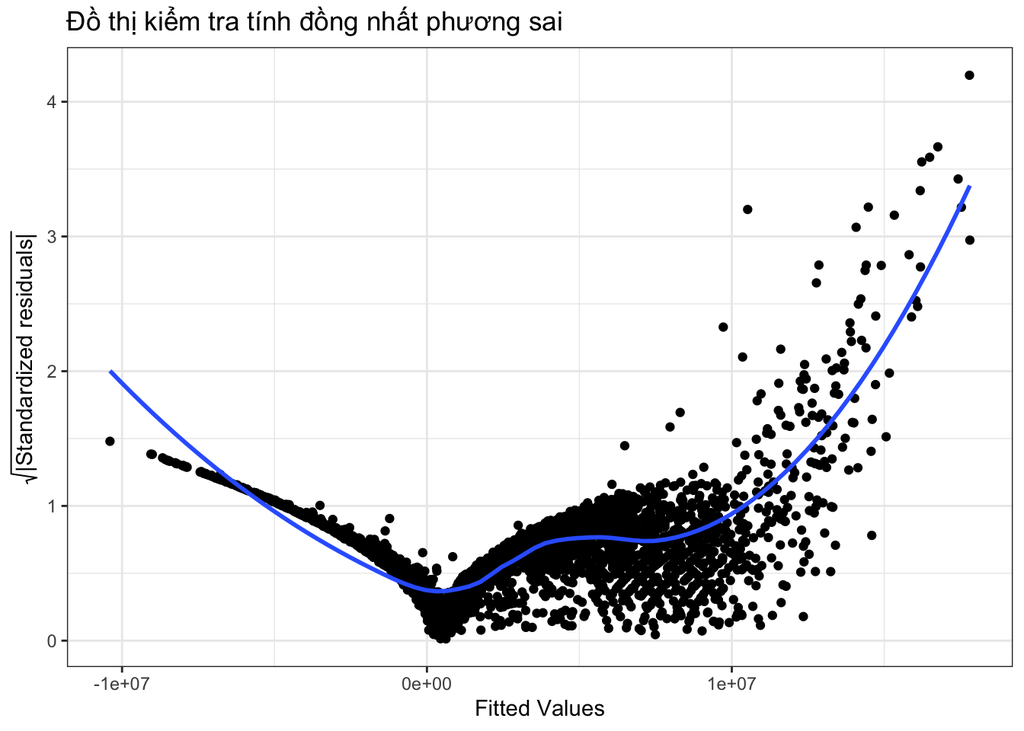

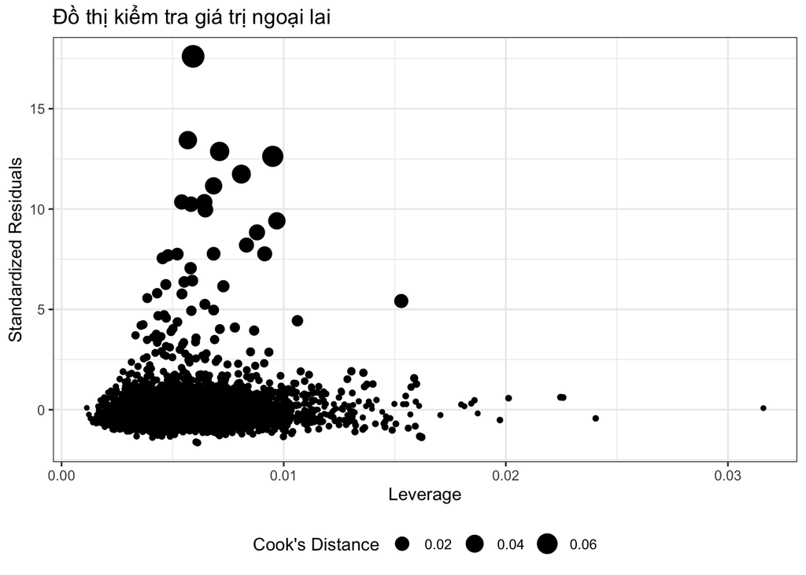

```r
model_diagnosis(model_mid_av)
```

##### DF

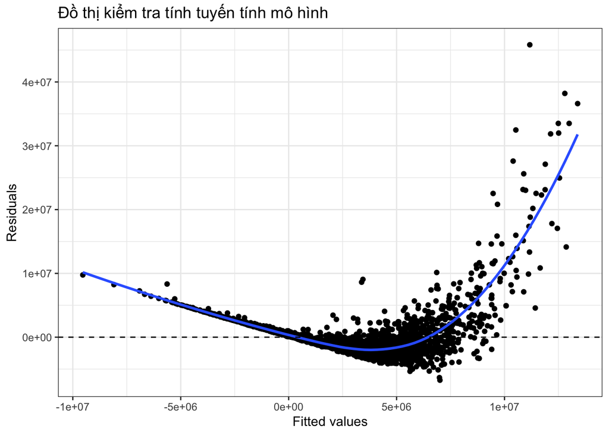

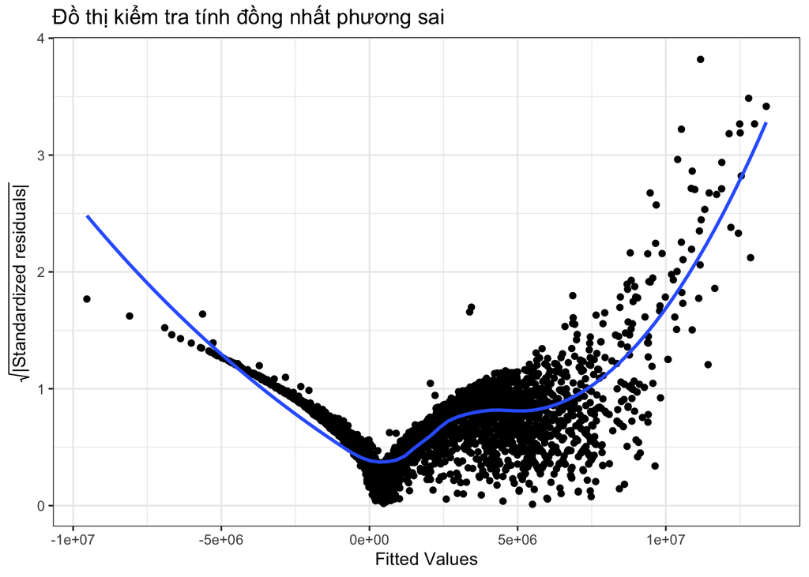

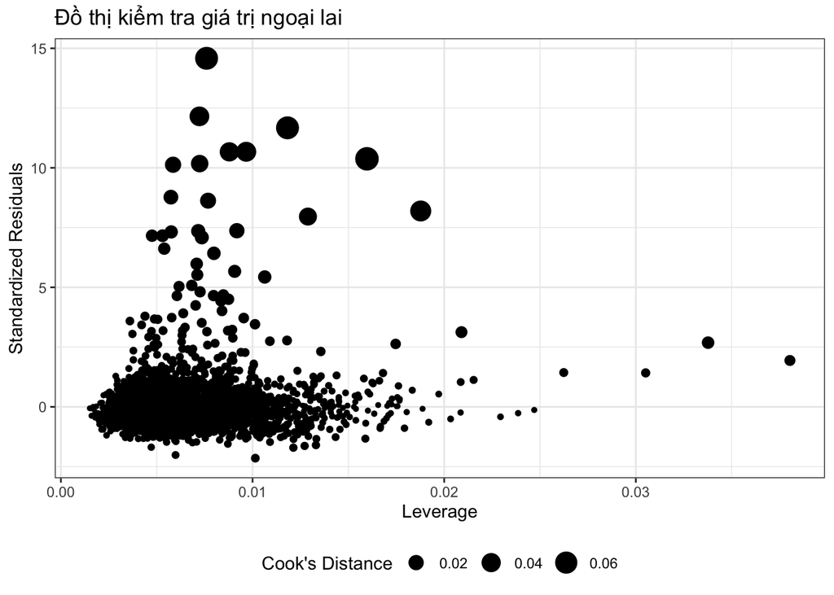

```r
model_diagnosis(model_df_av)
```

##### FW

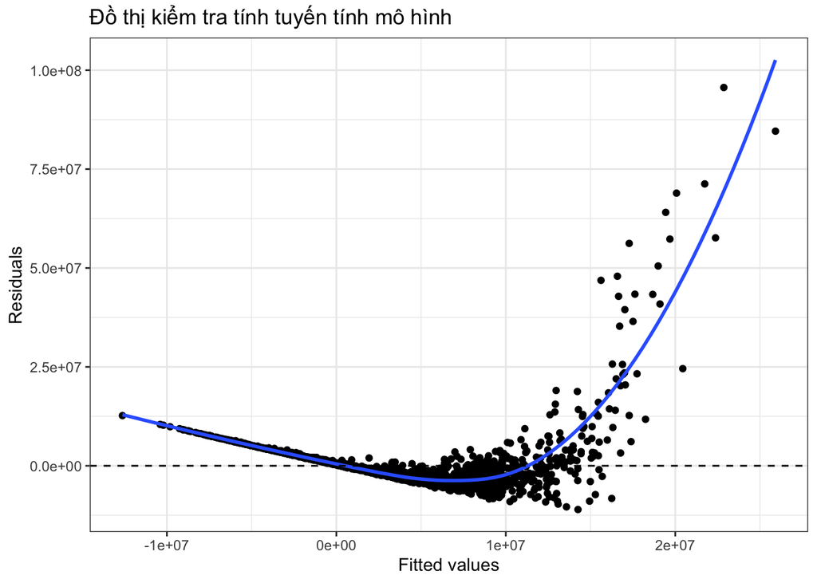

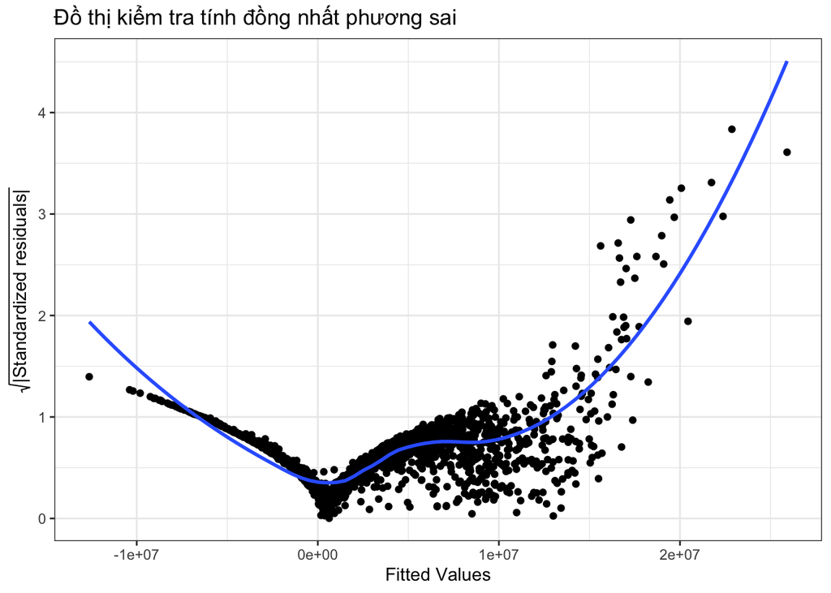

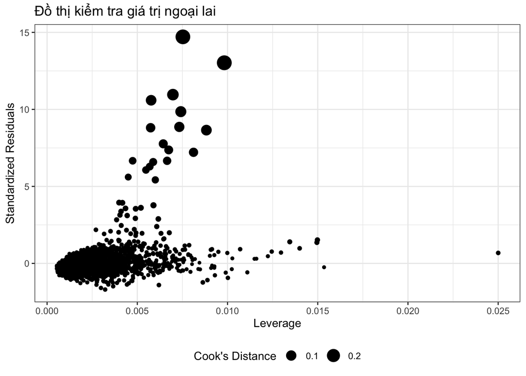

```r
model_diagnosis(model_fw_av)
```

*Nhận xét chung:* Cả 4 mô hình đều không thoả tính tuyến tính và đồng nhất phương sai.

### Kết luận cả 2 cách tiếp cận

- Cách tiếp cận với các biến non-technical cho ra mô hình dự đoán tốt giả trị cầu thủ, sử dụng ít biến và có thể tối ưu mô hình hơn để cho ra kết quả gần nhất có thể so với giá trị thực tế của cầu thủ.
- Cách tiếp cận với chỉ với các biến technical sử dụng 4 mô hình cho 4 nhóm vị trí khác nhau cho ra các dự đoán không tốt, các giá trị r2 dưới 0.5 mặc dù sử dụng nhiều biến; cả 4 model đều không thoả tính tuyến tính lẫn đồng nhất phương sai.

=> Như vậy, cách tiếp cận sử dụng các biến non-technical là cách tiếp cận tốt nhất cho bài toán 1 mà ta đang xét.

## Bài toán số 2: Dự đoán vị trí cầu thủ

```r
technical_cols_unGK = c(
  "weak_foot", "height", "weight",
  "crossing", "finishing", "heading_accuracy", "short_passing", "volleys",
  "dribbling", "curve", "fk_accuracy", "long_passing", "ball_control",
  "acceleration", "sprint_speed", "agility", "reactions", "balance",
  "shot_power", "jumping", "stamina", "strength", "long_shots",
  "aggression", "interceptions", "positioning", "vision", "penalties",
  "composure", "marking", "standing_tackle", "sliding_tackle"
)

# Lấy các cột này từ dữ liệu fifa_data
fifa_data_unGK <- fifa_data %>% filter(position != "GK")  # Loại bỏ GK
tech_data = fifa_data_unGK[, c(technical_cols_unGK, "position")]

head(tech_data)
```

```
## # A tibble: 6 × 33
##   weak_foot height weight crossing finishing heading_accuracy short_passing
##       <dbl>  <dbl>  <dbl>    <dbl>     <dbl>            <dbl>         <dbl>
## 1         4   5.7     159       84        95               70            90
## 2         4   6.2     183       84        94               89            81
## 3         5   5.9     150       79        87               62            84
## 4         5   5.11    154       93        82               55            92
## 5         4   5.8     163       81        84               61            89
## 6         4   5.8     146       86        72               55            93
## # ℹ 26 more variables: volleys <dbl>, dribbling <dbl>, curve <dbl>,
## #   fk_accuracy <dbl>, long_passing <dbl>, ball_control <dbl>,
## #   acceleration <dbl>, sprint_speed <dbl>, agility <dbl>, reactions <dbl>,
## #   balance <dbl>, shot_power <dbl>, jumping <dbl>, stamina <dbl>,
## #   strength <dbl>, long_shots <dbl>, aggression <dbl>, interceptions <dbl>,
## #   positioning <dbl>, vision <dbl>, penalties <dbl>, composure <dbl>,
## #   marking <dbl>, standing_tackle <dbl>, sliding_tackle <dbl>, …
```

### Cách tiếp cận cơ bản

```r
glimpse(tech_data)
```

```
## Rows: 14,743
## Columns: 33
## $ weak_foot        <dbl> 4, 4, 5, 5, 4, 4, 4, 3, 4, 5, 3, 2, 3, 3, 4, 3, 3, 4,…
## $ height           <dbl> 5.70, 6.20, 5.90, 5.11, 5.80, 5.80, 6.00, 6.00, 6.00,…
## $ weight           <dbl> 159, 183, 150, 154, 163, 146, 190, 181, 176, 168, 172…
## $ crossing         <dbl> 84, 84, 79, 93, 81, 86, 77, 66, 62, 88, 55, 84, 68, 8…
## $ finishing        <dbl> 95, 94, 87, 82, 84, 72, 93, 60, 91, 76, 42, 76, 65, 8…
## $ heading_accuracy <dbl> 70, 89, 62, 55, 61, 55, 77, 91, 85, 54, 92, 54, 54, 6…
## $ short_passing    <dbl> 90, 81, 84, 92, 89, 93, 82, 78, 83, 92, 79, 93, 86, 8…
## $ volleys          <dbl> 86, 87, 84, 82, 80, 76, 88, 66, 89, 82, 47, 82, 56, 8…
## $ dribbling        <dbl> 97, 88, 96, 86, 95, 90, 87, 63, 85, 81, 53, 89, 79, 9…
## $ curve            <dbl> 93, 81, 88, 85, 83, 85, 86, 74, 77, 86, 49, 82, 49, 8…
## $ fk_accuracy      <dbl> 94, 76, 87, 83, 79, 78, 84, 72, 86, 84, 51, 77, 49, 8…
## $ long_passing     <dbl> 87, 77, 78, 91, 83, 88, 64, 77, 65, 93, 70, 87, 81, 7…
## $ ball_control     <dbl> 96, 94, 95, 91, 94, 93, 90, 84, 89, 90, 76, 94, 80, 9…
```

[output cut: 20 more lines]

```r
set.seed(123)
split = sample.split(tech_data$position, SplitRatio = 0.7) # 70% train
tech_train = subset(tech_data, split == TRUE)
tech_test = na.omit(subset(tech_data, split == FALSE))
```

#### Model Logistic Regression đa lớp

```r
# Huấn luyện mô hình Logistic Regression đa lớp
logreg_model = nnet::multinom(position ~ ., data = tech_train)
# Dự đoán xác suất trên tập huấn luyện và kiểm tra
logreg_pred_train = predict(logreg_model, tech_train, type = "probs")
logreg_pred_test = predict(logreg_model, tech_test, type = "probs")

# Lấy nhãn dự đoán (class) từ xác suất cao nhất
logreg_class_train = colnames(logreg_pred_train)[max.col(logreg_pred_train)]
logreg_class_test = colnames(logreg_pred_test)[max.col(logreg_pred_test)]

# Tính Accuracy
logreg_accuracy_train <- mean(logreg_class_train == tech_train$position)
logreg_accuracy_test <- mean(logreg_class_test == tech_test$position)
print(paste("Logistic Regression Accuracy (Train):", round(logreg_accuracy_train, 4)))
```

```
## [1] "Logistic Regression Accuracy (Train): 0.4449"
```

```r
print(paste("Logistic Regression Accuracy (Test):", round(logreg_accuracy_test, 4)))
```

```
## [1] "Logistic Regression Accuracy (Test): 0.4324"
```

```r
roc_train_logreg <- multiclass.roc(tech_train$position, logreg_pred_train)
roc_test_logreg <- multiclass.roc(tech_test$position, logreg_pred_test)
auc_train_logreg <- auc(roc_train_logreg)
auc_test_logreg <- auc(roc_test_logreg)

print(paste("Logistic Regression AUC (Train):", round(auc_train_logreg, 4)))
```

```
## [1] "Logistic Regression AUC (Train): 0.892"
```

```r
print(paste("Logistic Regression AUC (Test):", round(auc_test_logreg, 4)))
```

```
## [1] "Logistic Regression AUC (Test): 0.8641"
```

Với acc = 0.4324 thì tương đối thấp đối với model Logistic Regression đa lớp. Tuy nhiên điều này có thể chấp nhận được vì bài toán này gốm rất nhiều class và có những lớp gần như tương đồng (rất khó phân biệt). Vì thế kết quả này có thể chấp nhận được.

#### Model Naive Bayes

```r
# Huấn luyện mô hình Naive Bayes
nb_model <- naiveBayes(position ~ ., data = tech_train)

# Dự đoán xác suất trên tập huấn luyện và kiểm tra
nb_pred_train <- predict(nb_model, tech_train, type = "raw")
nb_pred_test <- predict(nb_model, tech_test, type = "raw")

# Lấy nhãn dự đoán (class) từ xác suất cao nhất
nb_class_train <- colnames(nb_pred_train)[max.col(nb_pred_train)]
nb_class_test <- colnames(nb_pred_test)[max.col(nb_pred_test)]

# Tính Accuracy
nb_accuracy_train <- mean(nb_class_train == tech_train$position)
nb_accuracy_test <- mean(nb_class_test == tech_test$position)
print(paste("Naive Bayes Accuracy (Train):", round(nb_accuracy_train, 4)))
```

```
## [1] "Naive Bayes Accuracy (Train): 0.3534"
```

```r
print(paste("Naive Bayes Accuracy (Test):", round(nb_accuracy_test, 4)))
```

```
## [1] "Naive Bayes Accuracy (Test): 0.338"
```

```r
# Vẽ đường cong ROC cho Naive Bayes
roc_train_nb <- multiclass.roc(tech_train$position, nb_pred_train)
roc_test_nb <- multiclass.roc(tech_test$position, nb_pred_test)
auc_train_nb <- auc(roc_train_nb)
auc_test_nb <- auc(roc_test_nb)

print(paste("Naive Bayes AUC (Train):", round(auc_train_nb, 4)))
```

```
## [1] "Naive Bayes AUC (Train): 0.8773"
```

```r
print(paste("Naive Bayes AUC (Test):", round(auc_test_nb, 4)))
```

```
## [1] "Naive Bayes AUC (Test): 0.8574"
```

Tương tự như Logistic Regression đa lớp, Model Naive Bayes cũng có accuracy tương đối thấp, chỉ 0.338, thậm chí nhỏ hơn LR đa lớp. Nên ta sử dụng mô hình LR đa lớp có vẻ tốt hơn. Và phần sau ta chỉ mở rộng bài toán với mô hình LR đa lớp.

### Cách tiếp cận mở rộng

```r
# Chia dữ liệu thành tập huấn luyện và kiểm tra
set.seed(123)  # Đảm bảo kết quả ngẫu nhiên có thể tái lặp
train_indices <- sample(1:nrow(tech_data), size = 0.7 * nrow(tech_data))
train_data <- tech_data[train_indices, ]
test_data <- tech_data[-train_indices, ]

# Huấn luyện mô hình logistic regression đa lớp
library(nnet)
model_expand_2 = nnet::multinom(position ~ ., data = train_data)
# Dự đoán xác suất trên tập kiểm tra
predicted_probs = predict(model_expand_2, test_data, type = "probs")
```

```r
# Lấy ví dụ một mẫu ngẫu nhiên từ tập kiểm tra
set.seed(50)
sample_index = sample(1:nrow(test_data), 1)
sample_probs = predicted_probs[sample_index, ]
sample_actual = test_data$position[sample_index]

# Sắp xếp xác suất và loại bỏ vị trí thực tế
sorted_probs = sort(sample_probs, decreasing = TRUE)
main_class = sample_actual  # Lớp thực tế
main_class_prob = sorted_probs[main_class]

# Loại trừ vị trí thực tế khi tính top 3 vị trí nhầm
misclassified_probs = sorted_probs[names(sorted_probs) != sample_actual]
top3_misclassified_classes = names(misclassified_probs[1:3])
top3_misclassified_probs = misclassified_probs[1:3]

# In ra kết quả
cat("Mẫu ngẫu nhiên:\n")
```

```
## Mẫu ngẫu nhiên:
```

```r
cat("Vị trí thực tế:", sample_actual, "\n")
```

```
## Vị trí thực tế: CAM
```

```r
cat("Lớp dự đoán chính xác:", main_class, "với xác suất:", main_class_prob, "\n")
```

```
## Lớp dự đoán chính xác: CAM với xác suất: 0.4933683
```

```r
cat("Ba lớp dự đoán nhầm với xác suất cao nhất:\n")
```

```
## Ba lớp dự đoán nhầm với xác suất cao nhất:
```

```r
for (i in 1:3) {
  cat(top3_misclassified_classes[i], "với xác suất:", top3_misclassified_probs[i], "\n")
}
```

```
## CM với xác suất: 0.1965007
## CB với xác suất: 0.06742653
## LM với xác suất: 0.04145671
```

- Với ví dụ demo trên thì mẫu đưa vào là thông tin của CAM. thì mô hình tính toán xác suất dự đoán đúng khá cao 0.4933683, và quan trọng hơn là top3 vị trí xác suất dự đoán nhầm vào là CM, CB, LM. trong đó CM khá cao với 0.1965007. Cho thấy cầu thủ này có thể đá sang vị trí CM được. Với lý thuyết thực tế thì điều này khá hợp lý vì CAM với CM cũng dường như tương tự.
- Từ kết quả này ta có thể nói rằng mô hình này sẽ giúp câu lạc bộ đánh giá được khả năng linh hoạt vị trí của cầu thủ nào đó. Từ đó dễ dàng đưa ra quyết định mua hơn.

## Bài toán số 3: Dự đoán overall

```r
#Group theo position thành 2 class: GoalKeeper và UnGoalKeeper
numeric_fifa_data = fifa_data %>% dplyr::select(where(is.numeric))

position_mapping = list(
  Goalkeeper = c("GK"),
  UnGoalkeeper = c("CB", "LCB", "RCB", "LB", "RB", "LWB", "RWB", "CDM", "CM", "LCM", "RCM", "CAM", "LM", "RM", "LDM", "RDM", "LAM", "RAM", "CF", "ST", "LS", "RS", "RF", "LF", "LW", "RW")
)

# Tạo cột mới broad_position
fifa_data$broad_position = NA
for (broad_pos in names(position_mapping)) {
   fifa_data$broad_position[fifa_data$position %in% position_mapping[[broad_pos]]] = broad_pos
}

gk_data = numeric_fifa_data[fifa_data$broad_position == "Goalkeeper", ]
un_gk_data = numeric_fifa_data[fifa_data$broad_position == "UnGoalkeeper", ]
```

### Goalkeeper

#### Kiểm tra đa cộng tuyến

```r
m_GK <- lm(overall ~ gk_diving + gk_handling + gk_positioning + gk_reflexes + gk_kicking, gk_data)
vif(m_GK)
```

```
##      gk_diving    gk_handling gk_positioning    gk_reflexes     gk_kicking
##       6.417563       4.608270       5.115614       6.363458       2.324669
```

1 trong 2 biến gk_diving và gk_reflexes gây ra hiện tượng đa cộng tuyến. ta lựa chọn bỏ đi biến gk_diving

```r
m_GK <- lm(overall ~ gk_handling + gk_positioning + gk_reflexes + gk_kicking, gk_data)
vif(m_GK)
```

```
##    gk_handling gk_positioning    gk_reflexes     gk_kicking
##       4.482894       5.001887       3.778529       2.296927
```

Hiện tượng đa cộng tuyến đã được xử lý

#### Lựa chọn mô hình

```r
out_subset_m_GK <- regsubsets(x = overall ~ gk_handling + gk_positioning + gk_reflexes + gk_kicking,
                                             data = gk_data,
                                             nvmax = 4,
                                             method = "exhaustive")
sum_out_subset_m_GK <- summary(out_subset_m_GK)
sum_out_subset_m_GK$cp
```

```
## [1] 10170.1433  2151.2902   238.7864     5.0000
```

Ta thấy tập con gồm 4 biến cho kết quả tốt nhất

#### Chẩn đoán mô hình

##### Kiểm tra tính tuyến tính

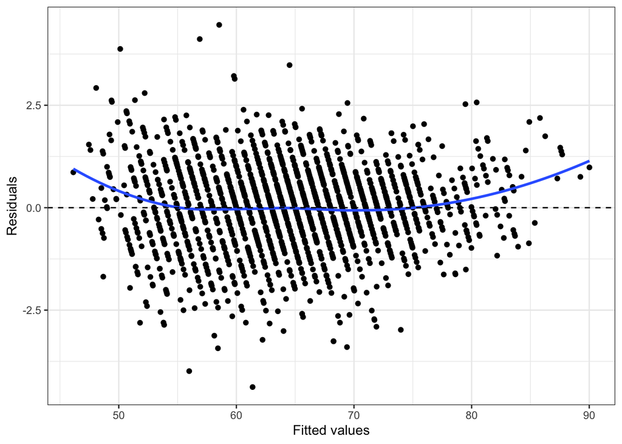

```r
ggplot(data = m_GK, mapping = aes(x = .fitted, y = .resid)) +
 geom_point() +
 geom_smooth(method = "loess", se = FALSE) +
 geom_hline(yintercept = 0, linetype = "dashed") +
 labs(x = "Fitted values", y = "Residuals") +
 theme_bw()
```

Giả định về tính tuyến tính của mô hình chưa phù hợp. Mô hình cũng không đồng nhất phương sai nên ta cân nhắc sử dụng GLM.

##### Kiểm tra giả định đồng nhất phương sai

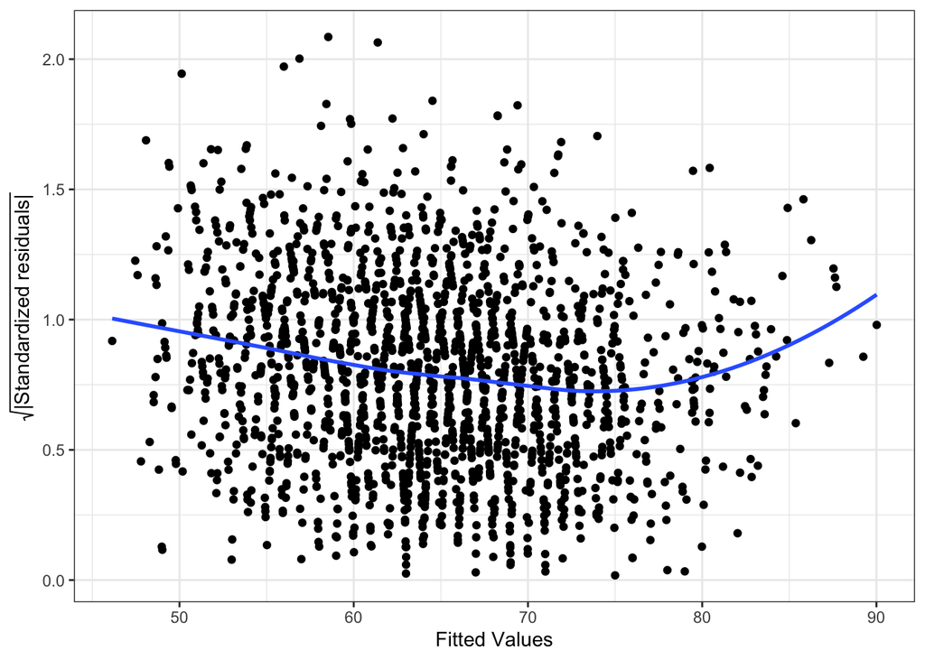

```r
ggplot(data = m_GK, mapping = aes(x = .fitted, y = sqrt(abs(.stdresid)))) +
 geom_point(na.rm = TRUE) +
 geom_smooth(method = "loess", se = FALSE, na.rm = TRUE) +
 labs(x = "Fitted Values", y = expression(sqrt("|Standardized residuals|"))) +
 theme_bw()
```

##### Kiểm tra giá trị ngoại lai

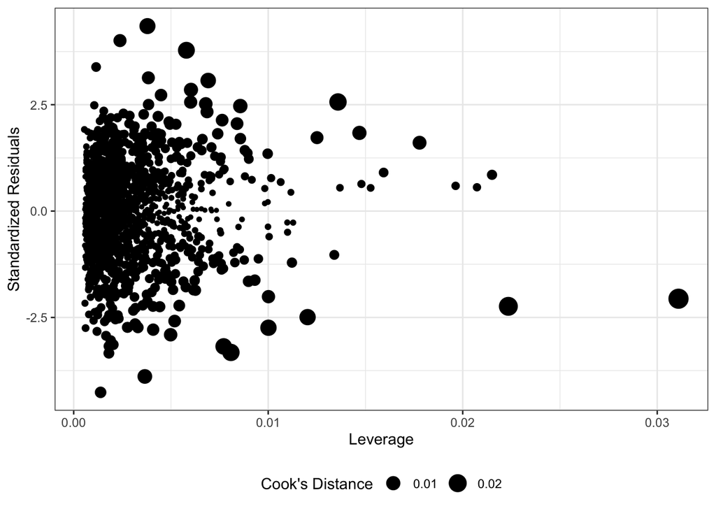

```r
ggplot(m_GK, aes(.hat, .stdresid)) +
 geom_point(aes(size = .cooksd)) +
 xlab("Leverage") + ylab("Standardized Residuals") +
 scale_size_continuous("Cook's Distance", range = c(1, 6)) +
 theme_bw() +
 theme(legend.position = "bottom")
```

Ngưỡng tham chiếu 4/n = 4/1900 = 0.002

```r
std_resid_m_GK <- rstandard(m_GK)
hat_values_m_GK <- hatvalues(m_GK)
cooks_D_m_GK <- cooks.distance(m_GK)

count1 <- sum(cooks_D_m_GK >= 0.002)
count2 <- sum(cooks_D_m_GK >= 0.003)
count3 <- sum(cooks_D_m_GK >= 0.004)

count1
```

```
## [1] 138
```

```r
count2
```

```
## [1] 71
```

```r
count3
```

```
## [1] 50
```

Các điểm có cook’s distance >= 0.002 chiếm khoảng 7% fifa_data, ta có thể bỏ chúng.

```r
gk_data <- gk_data[cooks_D_m_GK < 0.002, ]
```

#### Mở rộng mô hình

```r
m_GK_GLM <- glm(overall ~ gk_handling + gk_positioning + gk_reflexes + gk_kicking,
                data = gk_data,
                family = Gamma(link = "identity"))
m_GK_2 <- lm(overall ~ gk_handling + gk_positioning + gk_reflexes + gk_kicking,
             data = gk_data)
```

##### Đánh giá mô hình

```r
set.seed(110)

index <- createDataPartition(gk_data$overall, p = 0.7, list = FALSE)
train_data <- gk_data[index,]
test_data <- gk_data[-index,]

result_GK_1 <- evaluate_model(m_GK, train_data, test_data, "overall")
```

```
## Test results
## RMSE:  0.8710474
## R2_score:  0.9863008
```

```r
result_GK_2 <- evaluate_model(m_GK_2, train_data, test_data, "overall")
```

```
## Test results
## RMSE:  0.8709585
## R2_score:  0.9863036
```

```r
result_GK_3 <- evaluate_model(m_GK_GLM, train_data, test_data, "overall")
```

```
## Test results
## RMSE:  0.8713742
## R2_score:  0.9862906
```

Mô hình ban đầu hay mô hình mở rộng đều cho chỉ số r2_score gần như nhau và đều khá tốt 0.9863036 và 0.9862906. Cho thấy mô hình dự đoán rất tốt.

### UnGoalkeeper

Lựa chọn các thuộc tính cho cầu thủ phía trên thủ môn

```r
# Phần này có ở trên bài toán 1.2 nhưng để lại cho rõ
technical_cols_unGK = c("overall",
  "weak_foot", "height", "weight",
  "crossing", "finishing", "heading_accuracy", "short_passing", "volleys",
  "dribbling", "curve", "fk_accuracy", "long_passing", "ball_control",
  "acceleration", "sprint_speed", "agility", "reactions", "balance",
  "shot_power", "jumping", "stamina", "strength", "long_shots",
  "aggression", "interceptions", "positioning", "vision", "penalties",
  "composure", "marking", "standing_tackle", "sliding_tackle"
)

tech_data = un_gk_data %>% select(all_of(technical_cols_unGK))
```

#### Kiểm tra đa cộng tuyến

```r
m_un_GK <- lm(overall ~ ., tech_data)
vif(m_un_GK)
```

```
##        weak_foot           height           weight         crossing
##         1.130138         1.294326         2.626519         3.348438
##        finishing heading_accuracy    short_passing          volleys
##         7.057846         2.721405         6.428416         4.323175
##        dribbling            curve      fk_accuracy     long_passing
##         6.838996         4.472184         3.475158         5.016713
##     ball_control     acceleration     sprint_speed          agility
##         7.504988         5.803704         4.627689         3.748033
##        reactions          balance       shot_power          jumping
##         3.337259         3.149748         3.981182         1.450476
##          stamina         strength       long_shots       aggression
##         1.817281         3.518872         5.892590         2.523963
##    interceptions      positioning           vision        penalties
##         9.011422         4.965905         4.659523         2.944017
##        composure          marking  standing_tackle   sliding_tackle
##         3.199517         4.741031        20.177523        17.184783
```

Loại bỏ các biến gây ra hiện tượng đa cộng tuyến

```r
m_un_GK <- lm(overall ~ . -standing_tackle -finishing -interceptions -ball_control, tech_data)
vif(m_un_GK)
```

```
##        weak_foot           height           weight         crossing
##         1.127203         1.293506         2.623270         3.325664
## heading_accuracy    short_passing          volleys        dribbling
##         2.696789         5.581122         4.120567         5.315870
##            curve      fk_accuracy     long_passing     acceleration
##         4.454843         3.458634         4.976529         5.800793
##     sprint_speed          agility        reactions          balance
##         4.608518         3.725811         3.186331         3.148193
##       shot_power          jumping          stamina         strength
##         3.924330         1.446215         1.797631         3.499356
##       long_shots       aggression      positioning           vision
##         5.444921         2.449296         4.549269         4.620684
##        penalties        composure          marking   sliding_tackle
##         2.846229         3.122956         4.321043         5.479022
```

#### Lựa chọn mô hình

```r
out_subset_m_un_GK <- regsubsets(x = overall ~ . -standing_tackle -finishing -interceptions -ball_control,
                              data = tech_data,
                              nvmax = 28,
                              method = "exhaustive")
sum_out_subset_m_un_GK <- summary(out_subset_m_un_GK)
sum_out_subset_m_un_GK$cp
```

```
##  [1] 14538.66075  7493.57016  5696.32276  3297.11990  1979.33038  1329.15659
##  [7]  1093.41623   845.79088   688.89313   553.61751   422.47198   322.92711
## [13]   262.98354   210.71553   159.03385   116.80096    91.39614    72.59737
## [19]    59.58237    48.91908    40.83849    32.89465    29.11778    26.92969
## [25]    25.39239    26.19920    27.00669    29.00000
```

```r
# Xem tập biến con tốt nhất
sum_out_subset_m_un_GK$which[which.min(sum_out_subset_m_un_GK$cp),]
```

```
##      (Intercept)        weak_foot           height           weight
##             TRUE             TRUE             TRUE             TRUE
##         crossing heading_accuracy    short_passing          volleys
##             TRUE             TRUE             TRUE            FALSE
##        dribbling            curve      fk_accuracy     long_passing
##             TRUE             TRUE             TRUE             TRUE
##     acceleration     sprint_speed          agility        reactions
##             TRUE             TRUE             TRUE             TRUE
##          balance       shot_power          jumping          stamina
##             TRUE             TRUE            FALSE             TRUE
##         strength       long_shots       aggression      positioning
##             TRUE             TRUE            FALSE             TRUE
##           vision        penalties        composure          marking
##             TRUE             TRUE             TRUE             TRUE
##   sliding_tackle
##             TRUE
```

```r
# Xây dựng lại mô hình dựa trên tập biến con tốt nhất
m_un_GK <- lm(overall ~ . -standing_tackle -finishing -interceptions -ball_control -volleys -aggression -jumping,
              tech_data)
```

#### Chẩn đoán mô hình

##### Kiểm tra tính tuyến tính

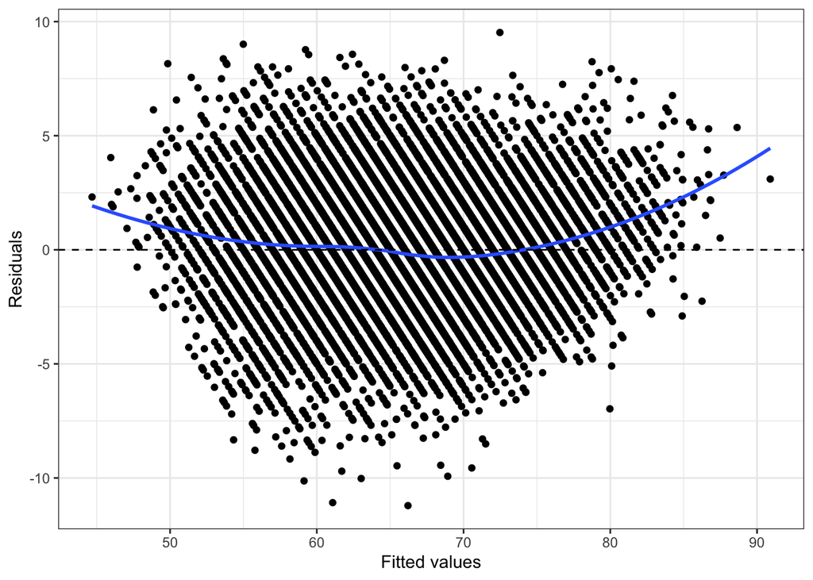

```r
ggplot(data = m_un_GK, mapping = aes(x = .fitted, y = .resid)) +
 geom_point() +
 geom_smooth(method = "loess", se = FALSE) +
 geom_hline(yintercept = 0, linetype = "dashed") +
 labs(x = "Fitted values", y = "Residuals") +
 theme_bw()
```

Giả định về tính tuyến tính của mô hình có vẻ chưa phù hợp.

##### Kiểm tra giả định đồng nhất phương sai

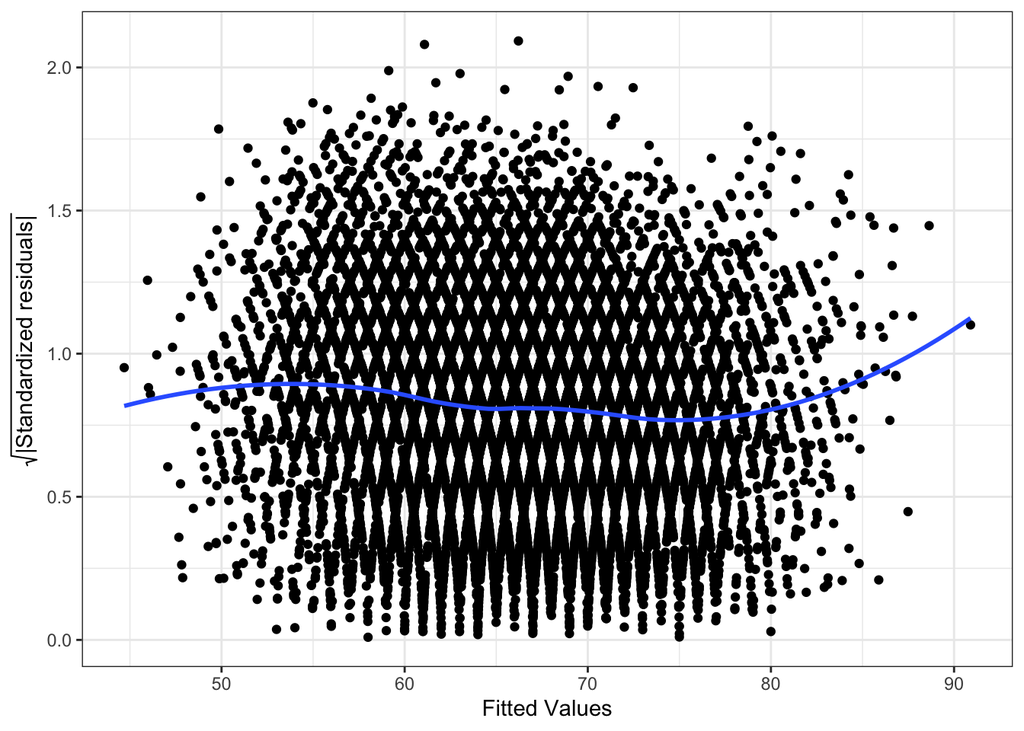

```r
ggplot(data = m_un_GK, mapping = aes(x = .fitted, y = sqrt(abs(.stdresid)))) +
 geom_point(na.rm = TRUE) +
 geom_smooth(method = "loess", se = FALSE, na.rm = TRUE) +
 labs(x = "Fitted Values", y = expression(sqrt("|Standardized residuals|"))) +
 theme_bw()
```

Mô hình không có sự đồng nhất phương sai.

##### Kiểm tra outliers

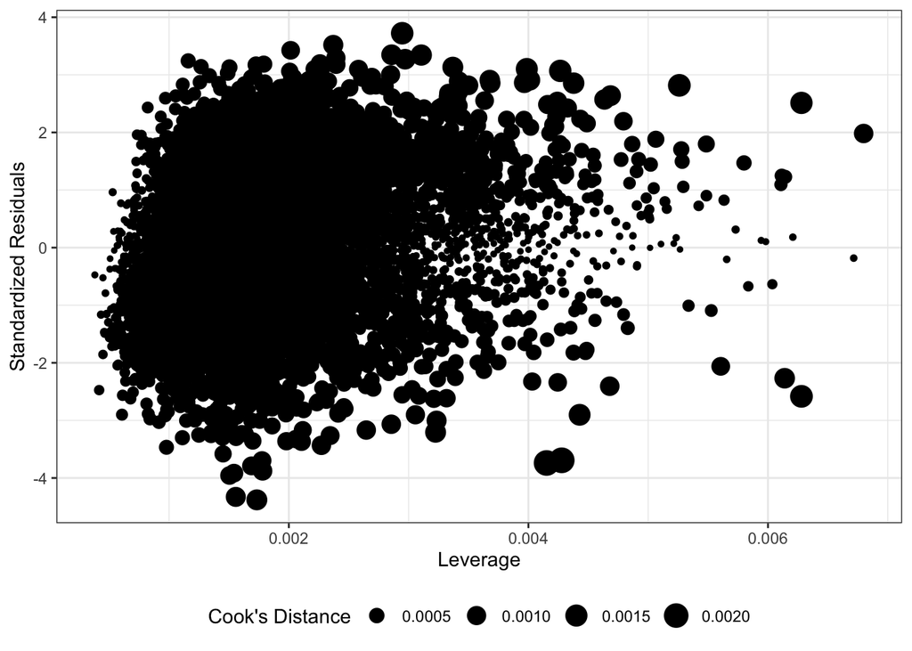

```r
ggplot(m_un_GK, aes(.hat, .stdresid)) +
 geom_point(aes(size = .cooksd)) +
 xlab("Leverage") + ylab("Standardized Residuals") +
 scale_size_continuous("Cook's Distance", range = c(1, 6)) +
 theme_bw() +
 theme(legend.position = "bottom")
```

Ngưỡng tham chiếu 4/n = 4/14743 = 0.0003

```r
std_resid_m_un_GK <- rstandard(m_un_GK)
hat_values_m_un_GK <- hatvalues(m_un_GK)
cooks_D_m_un_GK <- cooks.distance(m_un_GK)

count4 <- sum(cooks_D_m_un_GK >= 0.0003)
count5 <- sum(cooks_D_m_un_GK >= 0.0004)
count6 <- sum(cooks_D_m_un_GK >= 0.0005)

count4
```

```
## [1] 704
```

```r
count5
```

```
## [1] 405
```

```r
count6
```

```
## [1] 233
```

Những điểm dữ liệu có cook’s distance >= 0.0003 chiếm 4% fifa_data. Ta loại bỏ chúng

```r
tech_data <- tech_data[cooks_D_m_un_GK < 0.0003, ]
```

#### Mở rộng mô hình

```r
m_un_GK_GLM <- glm(overall ~ . -standing_tackle -finishing -interceptions -ball_control -volleys -aggression -jumping,
                data = tech_data,
                family = Gamma(link = "identity"))
m_un_GK_2 <- lm(overall ~ . -standing_tackle -finishing -interceptions -ball_control -volleys -aggression -jumping,
             data = tech_data)
```

##### Đánh giá mô hình

```r
index <- createDataPartition(tech_data$overall, p = 0.7, list = FALSE)
train_data <- tech_data[index,]
test_data <- tech_data[-index,]

result_un_GK_1 <- evaluate_model(m_un_GK, train_data, test_data, "overall")
```

```
## Test results
## RMSE:  2.259241
## R2_score:  0.888269
```

```r
result_un_GK_2 <- evaluate_model(m_un_GK_2, train_data, test_data, "overall")
```

```
## Test results
## RMSE:  2.256067
## R2_score:  0.8885828
```

```r
result_un_GK_3 <- evaluate_model(m_un_GK_GLM, train_data, test_data, "overall")
```

```
## Test results
## RMSE:  2.256761
## R2_score:  0.8885141
```

Mô hình ban đầu hay mô hình mở rộng đều cho chỉ số r2_score như nhau.

## Bài toán số 4: Dự đoán sự tiềm năng của cầu thủ

- Với đánh giá sơ bộ của cầu thủ thì nhóm xem xét các biến có khả năng ảnh hưởng đến tiềm năng (potential) của cầu thủ như là: age, overall, wage, value, international_reputation, height, weight, release_clause. Các biến kỹ thuật thì chỉ giải thích cho overall hơn là potential nên là ở bài toán này nhóm quyết định chỉ dùng số biến cơ sở ban đầu như trên.
- Bài toán này có nhiều cách tiếp cận, với potential là biến liên tục với giá trị [0,100] và tuân theo phân phối chuẩn nên việc dự đoán tiềm năng (theo cách phân loại) thì cần phải chuyển đổi biến sang định tính. Như đã nói vì potential tuân theo phân phối chuẩn nên việc chia nhóm cần phải thật kỹ, nhóm quyết định chia ra 2 cách tiếp cận. Một là chia thành 2 nhóm (trước mean và sau mean), cách tiếp cận này là cơ bản nhất vì dữ liệu cảu từng nhóm sẽ không bị imbalance. Cách thứ hai là chia làm 3 nhóm, cách này thì sẽ cần xem xét kỹ hơn nhưng lợi ích là phân loại rõ hơn. thay vì chỉ có “có tiềm năng” và “không tiềm năng”. Điều này giúp câu lạc bộ dễ đưa ra quyết định hơn. Tuy nhiên ta cần xử lý và xây dựng model để xem model với cách chia nào tốt hơn rồi mới đưa ra kết luận được.

### Cách tiếp cận 1: Chia potential thành 3 nhóm

```r
# Tính z-score và phân loại potential thành 3 nhóm
fifa_data_4 = fifa_data %>%
  mutate(
    z_score = (potential - mean(potential, na.rm = TRUE)) / sd(potential, na.rm = TRUE), # Tính z-score
    potential_class = case_when(
      z_score < -0.43 ~ 1, #Thấp
      z_score >= -0.43 & z_score <= 0.43 ~ 2, #Trung bình
      z_score > 0.43 ~ 3 #Cao
    )
  )

# Kiểm tra số lượng cầu thủ trong từng nhóm
table(fifa_data_4$potential_class)
```

```
##
##    1    2    3
## 5911 5205 5527
```

Số lượng cầu thủ trong từng nhóm phân bố tương đối đồng đều

```r
# Tính hệ số tương quan giữa các biến và potential_class
correlation_matrix <- cor(fifa_data_4 %>% select(age, overall, wage, value, international_reputation, height, weight, release_clause, potential_class), use = "complete.obs")

# Lấy hệ số tương quan của potential_class với các biến khác
correlation_with_class <- correlation_matrix["potential_class",]

# Chọn các biến có hệ số tương quan lớn hơn một ngưỡng nhất định (0.3)
selected_features <- names(correlation_with_class[abs(correlation_with_class) > 0.3])

# Hiển thị các biến được chọn
selected_features
```

```
## [1] "overall"         "wage"            "value"           "release_clause"
## [5] "potential_class"
```

#### Multinomial Logistic Regression

```r
# lặp 100 lần
set.seed(123)
m_potential = nnet::multinom(potential_class ~ age + overall + wage + release_clause, fifa_data_4, maxit = 100)
```

#### Đánh giá mô hình sử dụng confusion matrix và các điểm

```r
#confuse matrix
prod_pred_potential = predict(m_potential, type = "class")
conf_matrix_potential = table(fifa_data_4$potential_class, prod_pred_potential)

eval_multi_class = function(x) {
  cc <- sum(diag(x))
  sc <- sum(x)
  pp <- colSums(x)
  tt <- rowSums(x)
  ##
  prec <- diag(x)/colSums(x)
  recall <- diag(x)/rowSums(x)
  macro_prec <- mean(prec)
  macro_recall <- mean(recall)
  macro_f1 <- 2 * macro_prec * macro_recall/(1/macro_prec + 1/macro_recall)
  acc <- cc/sc
  kap <- (cc * sc - sum(pp * tt))/(sc^2 - sum(pp * tt))
  return(list(Precision = prec, Recall = recall, Accuracy = acc, Kappa = kap, Macro_F1 = macro_f1))
}
eval_multi_class(conf_matrix_potential)
```

```
## $Precision
##         1         2         3
## 0.8206384 0.7096131 0.8892662
##
## $Recall
##         1         2         3
## 0.8785316 0.6835735 0.8529039
##
## $Accuracy
## [1] 0.8090488
##
## $Kappa
## [1] 0.7128401
##
## $Macro_F1
## [1] 0.5231273
```

### Cách tiếp cận 2: Chia potential thành 2 nhóm

#### Tiền xử lý

```r
# Gán nhãn nhị phân dựa vào potential
# High Potential (1) nếu nó lớn hơn mean và ngược lại thì là Not High Potential là 0
mean_potential <- mean(fifa_data$potential, na.rm = TRUE)
# Gán nhãn nhị phân
fifa_data_4_2 <- fifa_data %>%
  mutate(potential_class = factor(ifelse(potential >= mean_potential, 1, 0)))

# Kiểm tra phân phối nhãn
table(fifa_data_4_2$potential_class)
```

```
##
##    0    1
## 9149 7494
```

Phân phối của các nhãn không quá chênh lệch.

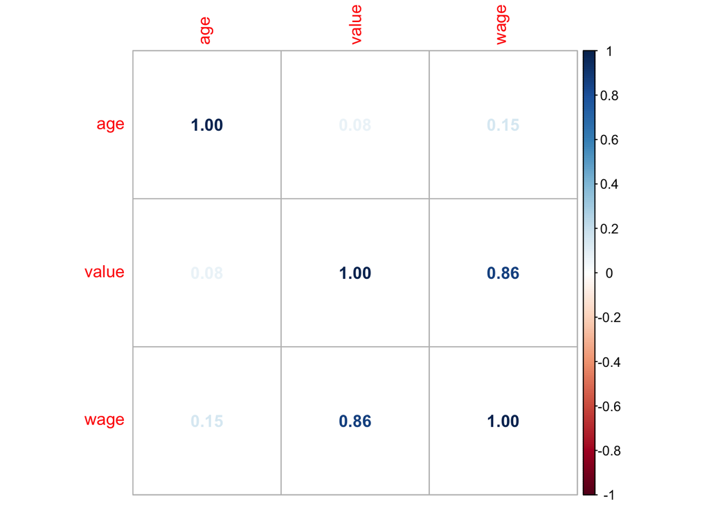

```r
# Kiểm tra tương quan
library(corrplot)
cor_matrix <- cor(fifa_data_4_2[, c("age", "value", "wage")])
corrplot(cor_matrix, method = "number")
```

Tương quan thấp giữa age với value và wage giúp các biến này đóng góp độc lập vào mô hình -> Lương của cầu thủ không phụ thuộc nhiều vào độ tuổi Tương quan cao giữa value và wage -> Cầu thủ có giá trị càng cao thì thường có mức lương càng cao

```r
# Chia dữ liệu thành tập huấn luyện và kiểm tra
set.seed(123)
train_data <- sample(nrow(fifa_data_4_2), 0.7 * nrow(fifa_data_4_2))
test_data <- setdiff(1:nrow(fifa_data_4_2), train_data)
train_data <- fifa_data_4_2[train_data, ]
test_data <- fifa_data_4_2[test_data, ]
```

1,Xây dựng mô hình hồi quy logistic dự đoán khả năng “High Potential”.

```r
out_md <- glm(formula = potential_class ~ age+ value + wage,data = train_data, family = binomial)
summary(out_md)
```

```
##
## Call:
## glm(formula = potential_class ~ age + value + wage, family = binomial,
##     data = train_data)
##
## Coefficients:
##               Estimate Std. Error z value Pr(>|z|)
## (Intercept)  8.661e+00  2.539e-01  34.116  < 2e-16 ***
## age         -5.231e-01  1.329e-02 -39.351  < 2e-16 ***
## value        3.607e-06  9.572e-08  37.685  < 2e-16 ***
## wage         5.322e-05  9.950e-06   5.349 8.86e-08 ***
## ---
## Signif. codes:  0 '***' 0.001 '**' 0.01 '*' 0.05 '.' 0.1 ' ' 1
##
## (Dispersion parameter for binomial family taken to be 1)
##
##     Null deviance: 16024.8  on 11649  degrees of freedom
## Residual deviance:  6486.6  on 11646  degrees of freedom
## AIC: 6494.6
##
## Number of Fisher Scoring iterations: 9
```

Ta thấy tất cả các giá trị p đều nhỏ hơn α = 0.05, điều đó có nghĩa là tất cả các biến đều có ý nghĩa thống kê đối với mô hình logistic điều này cho thấy rằng các biến này đóng vai trò quan trọng trong việc dự đoán biến phụ thuộc potential_class.

2: Đánh giá mô hình dựa trên 2 tập

Sử dụng ROC curve và AUC để đánh giá hiệu quả của mô hình.

```r
# Dự đoán và đánh giá mô hình trên tập huấn luyện
predictions_train <- predict(out_md, train_data, type = "response")
predictions_class_train <- ifelse(predictions_train > 0.5, 1, 0)
roc_train <- roc(train_data$potential_class~predictions_train)
cat("Train Results:\n")
```

```
## Train Results:
```

```r
auc_train<-roc_train$auc
cat("AUC: ", auc_train, "\n")
```

```
## AUC:  0.957627
```

AUC khá cao với kết quả 0.957627

```r
# Dự đoán và đánh giá mô hình trên tập kiểm tra
predictions_test <- predict(out_md, test_data, type = "response")
predictions_class_test <- ifelse(predictions_test > 0.5, 1, 0)
roc_test <- roc(test_data$potential_class~predictions_test)
cat("Test Results:\n")
```

```
## Test Results:
```

```r
auc_test<-roc_test$auc
cat("AUC: ", auc_test, "\n")
```

```
## AUC:  0.9542952
```

Mô hình có hiệu suất rất tốt với AUC > 0.95 trên cả tập train và test

```r
# Confusion Matrix trên tập test
conf_matrix <- confusionMatrix(
  factor(predictions_class_test),
  factor(test_data$potential_class)
)
print(conf_matrix)
```

```
## Confusion Matrix and Statistics
##
##           Reference
## Prediction    0    1
##          0 2545  362
##          1  175 1911
##
##                Accuracy : 0.8924
##                  95% CI : (0.8835, 0.9009)
##     No Information Rate : 0.5448
##     P-Value [Acc > NIR] : < 2.2e-16
##
##                   Kappa : 0.7817
##
##  Mcnemar's Test P-Value : 1.003e-15
##
##             Sensitivity : 0.9357
##             Specificity : 0.8407
##          Pos Pred Value : 0.8755
##          Neg Pred Value : 0.9161
##              Prevalence : 0.5448
##          Detection Rate : 0.5097
##    Detection Prevalence : 0.5822
##       Balanced Accuracy : 0.8882
##
##        'Positive' Class : 0
##
```

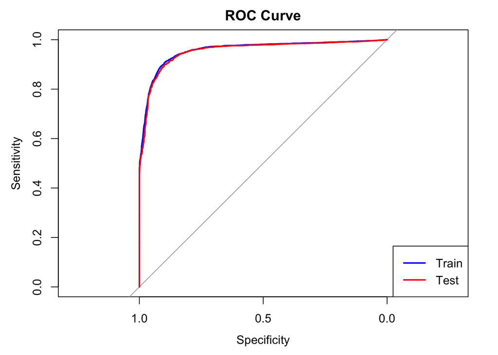

```r
# Vẽ đường cong ROC
plot(roc_train, main = "ROC Curve", col = "blue")
lines(roc_test, col = "red")
legend("bottomright", legend = c("Train", "Test"),
       col = c("blue", "red"), lwd = 2)
```

# —————————————————————–HẾT——————————————————————-